# Introduction To R - LSIRM 2018 3

Simon Kiss

2018-07-04

# Data Management

This is a good moment to introduce you to some basic data and code management principles that will hopefully make your life much easier. The basic idea is to break up your code into manageable chunks and save each chunk in a separate script.

By using the command `source()` you can execute R scripts linearly. What this means is that you can put some parts of your workflow in separate (i.e. more manageable chunks) and then source them in the next file. This has the added advantage of making analyses that you’ve done once before, executable for other projects when you need code you’ve written now.

In practice, what I usually do is end up having at least three separate working scripts. The first reads the data in and conducts any recodes, the second that conducts some analyses, and the third that does some gussying up producing nice looking plots and tables. In the second file, I source the first file, and in the third file, I source the first and second .R files and play with the plots. If I discover I need to change something (say, I need to change a variable to a dichotomous variable), then I can go back and either change the initial recode or add another one.

#### Assignment 1

> 1. Try sourcing in the file from yesterday.

```r
source('https://raw.githubusercontent.com/sjkiss/LSIRM_2018/master/2_LSIRM_2018.r')
```

# Tidy data

`ggplot()` really starts to sing, however, when we combine it with some of the newest innovations in R, namely the`dplyr` and the `tidyr`package. To introduce these, it is crucial to understand the difference between long and wide data.

In long (tidy) data, each column is one variable and each row is one observation. Currently our data very tidy, however, the difference between the two is sometimes blurry and can change depending on your purposes. Sometimes we want to *reshape* data from wide to long format. This can get to be a pretty technical - even philosophical - distinction, and we won’t go into it.

Here’s a quote from Hadley Wickham that illustrates this:

> A dataset is a collection of values, usually either numbers (if quantitative) or strings (if qualitative). Values are organised in two ways. Every value belongs to a variable and an observation. A variable contains all values that measure the same underlying attribute (like height, temperature, duration) across units. An observation contains all values measured on the same unit (like a person, or a day, or a race) across attributes [Wickham, 2018](https://cran.r-project.org/web/packages/tidyr/vignettes/tidy-data.html).

That said, sometimes it can be blurry and you might want to reshape data depending on the purpose. For example, you might be satisfied with two variables `home phone` and `work phone` in one context. But in another (e.g. fraud detection) you might want two different variables `phone type` and `phone_number`.

#### Assignment 2

> 1. How many variables are there in this data set? What are they?

```r
#print table1
table1
```

```
## # A tibble: 6 x 4
##   country      year  cases population
##   <chr>       <int>  <int>      <int>
## 1 Afghanistan  1999    745   19987071
## 2 Afghanistan  2000   2666   20595360
## 3 Brazil       1999  37737  172006362
## 4 Brazil       2000  80488  174504898
## 5 China        1999 212258 1272915272
## 6 China        2000 213766 1280428583
```

There are 4 variables. Superficially, the variables are named `country`, `year`, `cases` and `population`. However, a different way to conceptualize the data would be as follows.

```r
#Show table2
table2
```

```
## # A tibble: 12 x 4
##    country      year type            count
##    <chr>       <int> <chr>           <int>
##  1 Afghanistan  1999 cases             745
##  2 Afghanistan  1999 population   19987071
##  3 Afghanistan  2000 cases            2666
##  4 Afghanistan  2000 population   20595360
##  5 Brazil       1999 cases           37737
##  6 Brazil       1999 population  172006362
##  7 Brazil       2000 cases           80488
##  8 Brazil       2000 population  174504898
##  9 China        1999 cases          212258
## 10 China        1999 population 1272915272
## 11 China        2000 cases          213766
## 12 China        2000 population 1280428583
```

Here, the 4 variables are different: `country`, `year`, `type` (i.e. type of count or group of people) and `count`.

The reason that it is worth thinking about how you want your data to be shaped is that it can facilitate easy visualization and analysis.

The `tidyr` package makes it remarkably easy to reshape data from long to wide and vice verse. The key function is the `gather()` function. It takes the data frame you want to reshape (e.g. gather) as the first argument, then it takes two arguments, the defaults are `Variable` and `value`. Lastly, you can specify specifically which columns you want to `gather()`

To deal with the example above we want to fold the two variables `cases` and `population` into two new variables. We dont’ want to touch the variables `country` and `year`

So it looks like this.

```r
  #Gather the data frame, name new columns Variable, Value, do not touch country and year
gather(table1, Variable, Value, cases, population)
```

```
## # A tibble: 12 x 4
##    country      year Variable        Value
##    <chr>       <int> <chr>           <int>
##  1 Afghanistan  1999 cases             745
##  2 Afghanistan  2000 cases            2666
##  3 Brazil       1999 cases           37737
##  4 Brazil       2000 cases           80488
##  5 China        1999 cases          212258
##  6 China        2000 cases          213766
##  7 Afghanistan  1999 population   19987071
##  8 Afghanistan  2000 population   20595360
##  9 Brazil       1999 population  172006362
## 10 Brazil       2000 population  174504898
## 11 China        1999 population 1272915272
## 12 China        2000 population 1280428583
```

Now let’s turn to our data frame:

```r
#print vars
print(vars)
```

```
## $p_incineq
## [1] "Is income inequality a big problem in Canada?"
##
## $income_full
## [1] "Combination of income_grp and income_TEXT"
##
## $p_selfplace
## [1] "In politics, people sometimes talk of left and right. Where would you place your"
##
## $education
## [1] "What is the highest level of education that you have completed? [AA]"
##
## $p_votechce
## [1] "Which party did you vote for?"
##
## $pers_ret
## [1] "Over the past year, has your financial situation: [AA]"
##
## $pers_fdpol
## [1] "And have the policies of the FEDERAL government made your financial situation: ["
##
## $p_gap
## [1] "How much do you think should be done to reduce the gap between the rich and the"
##
## $sex_r
## [1] "Are you? [This will Auto-Advance on choice]"
```

The variables `pers_ret` and `pers_fdpol` were both variables about a person’s financial situation. The only difference was the first was about the person’s financial situatino in general and the second was about whether the federal government had any impact on that.

We might want to visualize the distribution of both responses in one plot. But because they are stored in two separate variables, this would be *very* hard to do in base-R. This is a problem that the tidyverse was developed to solve.

One problem we face is that `pers_ret` and `pers_fdpol` are `labelled` variables. Take a look.

```r
#Show pers_ret
head(ces$pers_ret)
```

```
## <Labelled double>
## [1]  2 NA  3  2  3  2
##
## Labels:
##  value                 label
##      1         Gotten Better
##      2          Gotten Worse
##      3 Stayed About the Same
##      4            Don't Know
##      5      Refuse to Answer
##    998    Don't Know/Refused
##   1000 Seen But Not Answered
```

```r
#Show pers_fdpol
head(ces$pers_fdpol)
```

```
## <Labelled double>
## [1]  3 NA  3  3  3  3
##
## Labels:
##  value                 label
##      1                Better
##      2                 Worse
##      3   Stay About the Same
##      4            Don't Know
##      5      Refuse to Answer
##    998    Don't Know/Refused
##   1000 Seen But Not Answered
```

Part of the problem stems from the fact that the value labels are not in a meaningful order, i.e. `1=Better`, but `2=Worse`, but `3=Stayed the same`.That is not our fault, but it is our problem. It would be more intuitive to have the levels go from one extreme to the other.

We coudl attack this from a number of ways. The easiest way, though would be as follows.

#### Assignment 3

> 1.Recode the variables `pers_ret` and `pers_fdpol` into two new variables. Save them as `personal` and `federal`. This relies on turning the `labelled` variable into a `number` with the function `as.numeric()`. The `Recode()` function **does not work** with labelled variables. Set the levels to go in an order from `Worse` to `Better`.

```r
ces$personal<-Recode(as.numeric(ces$pers_ret),
                     "1='Better' ; 2='Worse' ; 3='Same'",
                     levels=c('Worse', 'Same' ,'Better'), as.factor=T)
#federal policies
ces$federal<-Recode(as.numeric(ces$pers_fdpol),
                    "1='Better' ; 2='Worse' ; 3='Same'",
                    levels=c('Worse', 'Same' ,'Better'), as.factor=T)
```

#### Assignment 4

> 1. Gather `personal` and `federal` into one variable called `Finances`. Store them in a new data frame as out.Check the names of `out` to be sure that it worked. Plot with a barplot the distribution of responses facetting now by the new variable Finances.

```r
str(ces)
#Examine variables
ces$personal
ces$federal
```

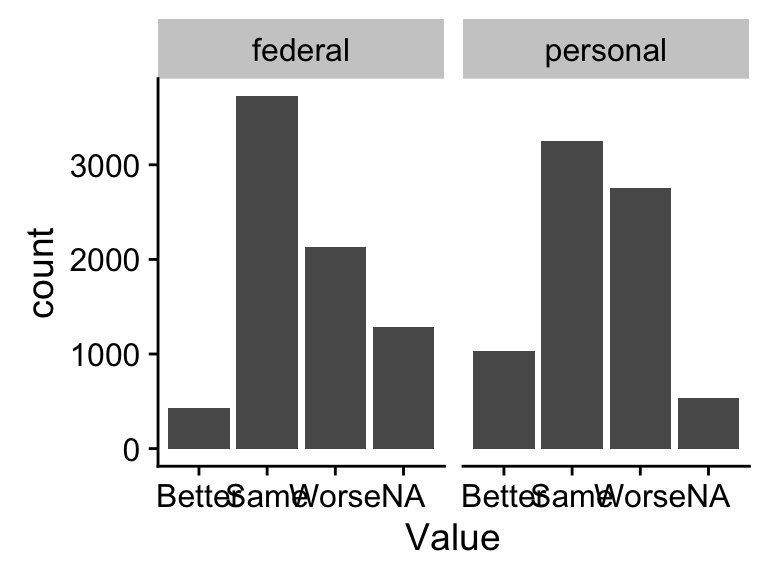

```r
#Store the results of the command in out. Note, this can be added at the end, once you know you have the command correct.
# Start with the data frame

  #Gather, name the new variables, then select the variables to be gathered
out<-gather(ces, Finances, Value, personal, federal )

#names
names(out)
#

#plot
ggplot(out, aes(x=Value))+geom_bar()+facet_grid(~Finances)
```

## Filtering and Selecting

The tidyverse is meant to accomplish a few things. One of these things is to improve the readability of R code. Base R can be quite messy.

One of the key innovations in the `tidyverse()` is the use of this character `%>%`. This is a pipe that sends the results of one command to the command on the next line. Technically, this character only works when the `magritr` library is loaded, but this is always loaded automatically when you run `library(tidyverse)` so you almost never have to worry about it.

Another big issue is consistency. The `tidyverse()` is built ona consistent set of design principles that make it easier to use.

For example, the base R way to select a few variables is to use the `subset()` command with the `select` argument:

```r
subset(ces, select=c('gender', 'ideology'))
```

```
## # A tibble: 7,572 x 2
##    gender ideology
##    <fct>     <dbl>
##  1 M             8
##  2 F             6
##  3 M            NA
##  4 F            NA
##  5 M            NA
##  6 F            NA
##  7 M             4
##  8 M             3
##  9 M             5
## 10 M             8
## # ... with 7,562 more rows
```

The same command is used to subset *cases* , not just variables.

```r
#This selects only males
subset(ces, select='gender',gender=='M')
```

```
## # A tibble: 3,635 x 1
##    gender
##    <fct>
##  1 M
##  2 M
##  3 M
##  4 M
##  5 M
##  6 M
##  7 M
##  8 M
##  9 M
## 10 M
## # ... with 3,625 more rows
```

By contrast the tidyverse uses two separate commands for these two different functions: `filter()` and `select()`

```r
filter(ces, gender=='M')
```

```
## # A tibble: 3,635 x 17
##    p_incineq income_full p_selfplace education p_votechce pers_ret
##    <dbl+lbl> <dbl+lbl>         <dbl>     <dbl> <dbl+lbl>  <dbl+lbl>
##  1 1         5                     8         9 1          2
##  2 <NA>      1                    NA         7 <NA>       3
##  3 3         2                  1000        10 1          3
##  4 1         3                     4         7 <NA>       1
##  5 1         3                     3        11 3          1
##  6 3         4                     5         5 1          2
##  7 2         1                     8         7 1          1
##  8 <NA>      7                    NA         4 <NA>       5
##  9 1         4                     6        10 1          3
## 10 <NA>      4                    NA         5 <NA>       2
## # ... with 3,625 more rows, and 11 more variables: pers_fdpol <dbl+lbl>,
## #   p_gap <dbl+lbl>, sex_r <dbl+lbl>, inequal <dbl>, gender <fct>,
## #   degree <fct>, income <dbl>, ideology <dbl>, inequal_cat <fct>,
## #   personal <fct>, federal <fct>
```

```r
select(ces, c(gender, ideology))
```

```
## # A tibble: 7,572 x 2
##    gender ideology
##    <fct>     <dbl>
##  1 M             8
##  2 F             6
##  3 M            NA
##  4 F            NA
##  5 M            NA
##  6 F            NA
##  7 M             4
##  8 M             3
##  9 M             5
## 10 M             8
## # ... with 7,562 more rows
```

```r
ces %>%
  filter(gender=='M') %>%
  select(gender, ideology)
```

Now, we can even feed that into ggplot2 to draw a histogram of men’s ideology scores. Note that because we are feeding the data frame line-by-line to the next function, there is no need to name the data frame in the ggplot2 command, we can just substitute it with a `.`

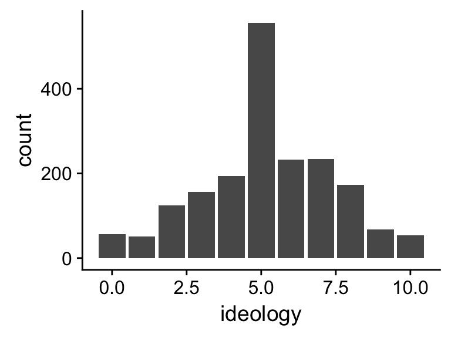

```r
#Start with a data frame
ces %>%
  #Filter out men
  filter(gender=='M') %>%
  #select the variable you want
  select(ideology) %>%
  #Do something you want
  ggplot(., aes(x=ideology))+geom_bar()
```

#### Assignment 5

> 1. In the plot for Assignment 4 that we made, there were missing values that were reported. Eliminate the missing values using `filter()` and `is.na()`.

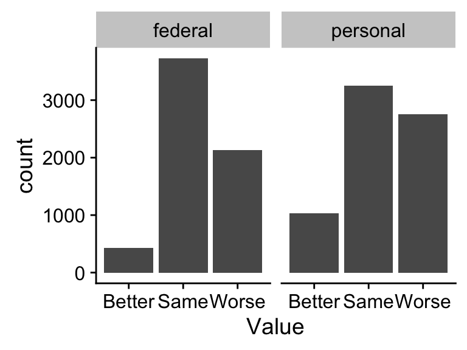

```r
#check out
str(out)
#Start with out as a data frame
out %>%
  #filter out missing values on the value label
  filter(is.na(Value)==F) %>%
  #plot
  ggplot(., aes(Value))+geom_bar()+facet_grid(~Finances)
```

## Grouping, summarizing and mutating

### Selecting, counting group membership.

In the first class we learned how to use the `table()` command to create contingency tables. It works really well, but it breaks down somewhat when trying to create tables of three or more variables.

The `tidyverse` makes it extremely easy.

The central concepts that make it easy are `grouping` , `summarizing` and `mutating`. All have their own functions with those names: `group_by()`, `summarise()` and `mutate`.

Grouping a data frame prepares it for analysis based on the values of the grouping variable.

Summarizing that data frame then performs some analysis on each group formed by the grouping variable. Suppose we want to compare `gender`, `degree` and `vote`.

Mutating transforms an existing column into a new column and adds it to the existing data frame.

First we can `select` the three variables of interest, and save them in a temporary data frame called `out`. We could use any name, but `out` is useful because it is quick to type, and sort of implies something temporary. Others also often use `tmp` or `temp`. I often use `test`.

```r
names(ces)
```

```
##  [1] "p_incineq"   "income_full" "p_selfplace" "education"   "p_votechce"
##  [6] "pers_ret"    "pers_fdpol"  "p_gap"       "sex_r"       "inequal"
## [11] "gender"      "degree"      "income"      "ideology"    "inequal_cat"
## [16] "personal"    "federal"
```

```r
out<-ces %>%
  select(gender, degree, p_votechce)
#Check the results
out
```

```
## # A tibble: 7,572 x 3
##    gender degree    p_votechce
##    <fct>  <fct>     <dbl+lbl>
##  1 M      Degree    1
##  2 F      <NA>      1
##  3 M      No degree <NA>
##  4 F      No degree <NA>
##  5 M      Degree    1
##  6 F      Degree    <NA>
##  7 M      No degree <NA>
##  8 M      Degree    3
##  9 M      No degree 1
## 10 M      No degree 1
## # ... with 7,562 more rows
```

#### Assignment 6

> 1. Recode `p_votechce` to include only Conservative, NDP, Liberal, BQ voters . Store it in `vote`. Remember to use `vals` and `as.numeric`.

```r
ces$vote<-Recode(as.numeric(ces$p_votechce), "1='Conservative' ; 2='Liberal' ; 3='NDP'; 4='BQ' ; else=NA", levels=c('Conservative', 'Liberal', 'NDP', 'BQ'), as.factor=T)
```

Now we can reselect and form groups with `group_by`

```r
#We will start with `ces`
out<-ces %>%
  #select gender, degree and vote
  select(gender, degree, vote) %>%
  #Form groups of gender and degree
  group_by(gender, degree, vote)
#print
out
```

```
## # A tibble: 7,572 x 3
## # Groups:   gender, degree, vote [39]
##    gender degree    vote
##    <fct>  <fct>     <fct>
##  1 M      Degree    Conservative
##  2 F      <NA>      Conservative
##  3 M      No degree <NA>
##  4 F      No degree <NA>
##  5 M      Degree    Conservative
##  6 F      Degree    <NA>
##  7 M      No degree <NA>
##  8 M      Degree    NDP
##  9 M      No degree Conservative
## 10 M      No degree Conservative
## # ... with 7,562 more rows
```

The next thing to do is to `summarize` the groups by counting how many respondents are in each group. Inside the `summarise` command, we call a function `n()` which counts the number of cases in a group.

```r
#Call out, which we stored above
out<-out %>%
  #Summarize groups, provide a name for the new variable
  summarize(number=n()) %>%
#Filter out missing values
na.omit()
```

And then we can plot. Note: when we have pre-caclulated the group values, we can plot it with `geom_col` (short for column)

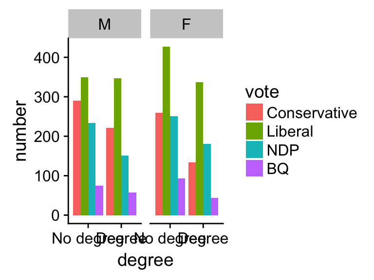

```r
out %>%
  ggplot(., aes(x=degree, y=number, fill=vote))+geom_col(position='dodge')+facet_grid(~gender)
```

You can specify which colors to use. We do this by changing the `scale`. Again, the whole `tidyverse` is really built on consistency, which is really great. To access the nature of the scales in a plot, you can specify `scale_fill_manual`. Note: we use `scale_fill` because we are working with a barplot. If we were working with a lineplot and wanted to change the line color, we would specify `scale_color_manual`. And if we wanted to modify the linetype, we would specify `scale_linetype_manual`.

Inside `scale_fill_manual` you simply set the values. They apply to the order of the factor levels of the grouping variable, in this case, `vote`.

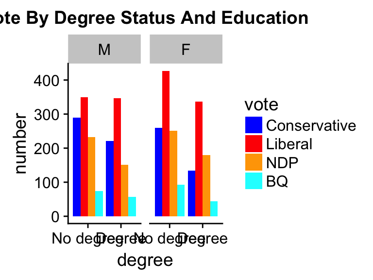

```r
  out %>%
  ggplot(., aes(x=degree, y=number, fill=vote))+geom_col(position='dodge')+facet_grid(~gender)+scale_fill_manual(values=c('blue', 'red', 'orange', 'cyan'))+labs(title='Vote By Degree Status And Education')
```

#### Assignment 7

> 1. we also have a variable `inequal_cat` which asks whether inequality is a big problem in Canada. Count the numer of people who think so by degree status (`degree`) income (`income`) and vote (`vote`)

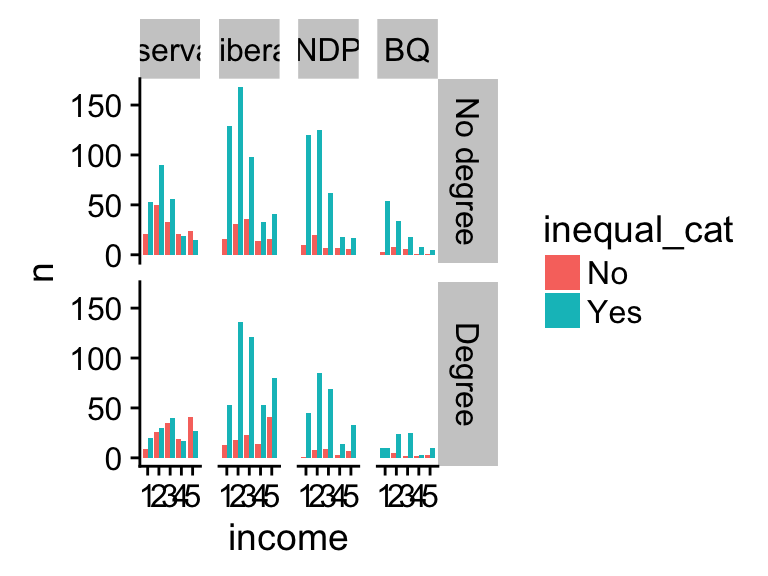

```r
ces %>%
select(degree, vote, income, inequal_cat) %>%
  group_by(degree, vote, income, inequal_cat) %>%
  summarize(n=n()) %>%
  na.omit() %>%
  ggplot(., aes(x=income, y=n, fill=inequal_cat))+geom_col(position='dodge')+facet_grid(degree~vote)
```

### Mutating to calculate percentages

Often we want to go further then just summarizing groups and we want to transform a variable. This is `mutating`. Note that the table we produced above, summarizing group memberships does not give us the table **percentages**. Sometimes the raw frequencies are good enough, sometimes we want percentages.

What we want to do is transform the results of the `summarise` function counting the group memberships to report the proportion of each group.

Here is how we would calculate the percentages of the table on `degree`, `gender` and `vote`.

Note that we need to form *new* groups just before mutating, because we want to take the group size and divide it by the size of the party group out of the size of the overall group of, for example `men with no degrees`

```r
#Start with ces
ces %>%
  #Select variables of interest
  select(gender, degree, vote) %>%
  #group
  group_by(gender, degree, vote) %>%
  #summarize
  summarise(n=n()) %>%
  #na.omit
  na.omit() %>%
 #Here is our mutate command
mutate(pct=n/sum(n))
```

```
## # A tibble: 16 x 5
## # Groups:   gender, degree [4]
##    gender degree    vote             n    pct
##    <fct>  <fct>     <fct>        <int>  <dbl>
##  1 M      No degree Conservative   290 0.306
##  2 M      No degree Liberal        350 0.370
##  3 M      No degree NDP            233 0.246
##  4 M      No degree BQ              74 0.0781
##  5 M      Degree    Conservative   221 0.285
##  6 M      Degree    Liberal        347 0.447
##  7 M      Degree    NDP            151 0.195
##  8 M      Degree    BQ              57 0.0735
##  9 F      No degree Conservative   260 0.252
## 10 F      No degree Liberal        427 0.414
## 11 F      No degree NDP            251 0.243
## 12 F      No degree BQ              93 0.0902
## 13 F      Degree    Conservative   134 0.193
## 14 F      Degree    Liberal        337 0.485
## 15 F      Degree    NDP            180 0.259
## 16 F      Degree    BQ              44 0.0633
```

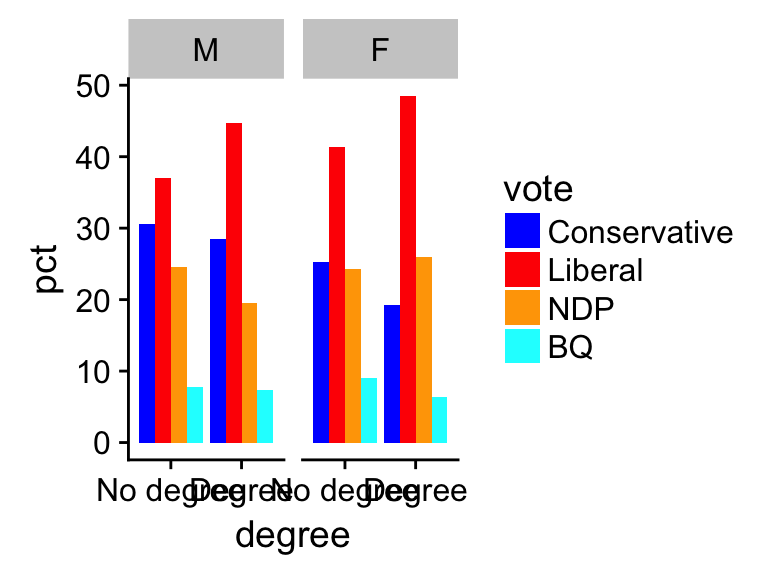

```r
#Start with ces
ces %>%
  #Select variables of interest
  select(gender, degree, vote) %>%
  #group
  group_by(gender, degree, vote) %>%
  #summarize
  summarise(n=n()) %>%
  #na.omit
  na.omit() %>%
 #Here is our mutate command, pay attention to the brackets
mutate(pct=(n/sum(n))*100) %>%
  #plot, note the new y-axis-value
  ggplot(., aes(x=degree, y=pct, fill=vote))+geom_col(position='dodge')+facet_grid(~gender)+scale_fill_manual(values = c('blue', 'red', 'orange', 'cyan'))
```

#### Assignment 8

> 1. Reproduce the summary of group memberships from the previous assignment. Calculate the group percentages and plot.

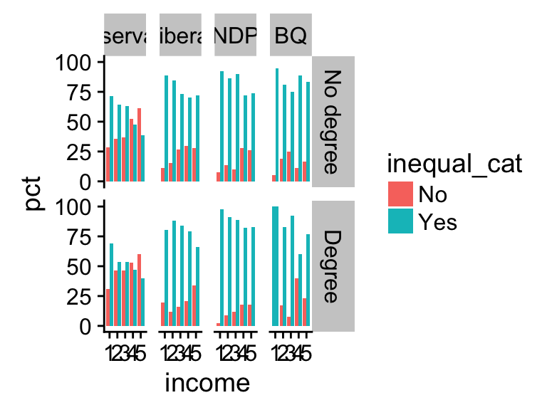

```r
#Start with the data frame
ces %>%
  #select variables of interest
select(degree, vote, income, inequal_cat) %>%
  #form the groups
  group_by(degree, vote, income, inequal_cat) %>%
  #and count
  summarize(n=n()) %>%
  #eliminate missing values
  na.omit() %>%
  #form new groups for mutating
  group_by(degree, vote, income) %>%
  #mutate
  mutate(pct=(n/sum(n)*100)) %>%
  #plot
  ggplot(., aes(x=income, y=pct, fill=inequal_cat))+geom_col(position='dodge')+facet_grid(degree~vote)
```

### Mutating to recode

We can also use mutating to recode variables as we need them.

#### Assignment 9

> 1. Suppose we want to do the same caculation as in Assignment 8, but we have too many income categories. Use mutate() and recode() to reduce the number of income categories to three (< 30, 30 to 110 and more than 110). Check `vals` to check the levels you need to recode. Remember you can use the `:` to select a range of values to recode. Remember to set the levels in a useful order. The levels need to be specified *exactly* as the new values of the factor. Store the new variable as income 2. Plot as above.

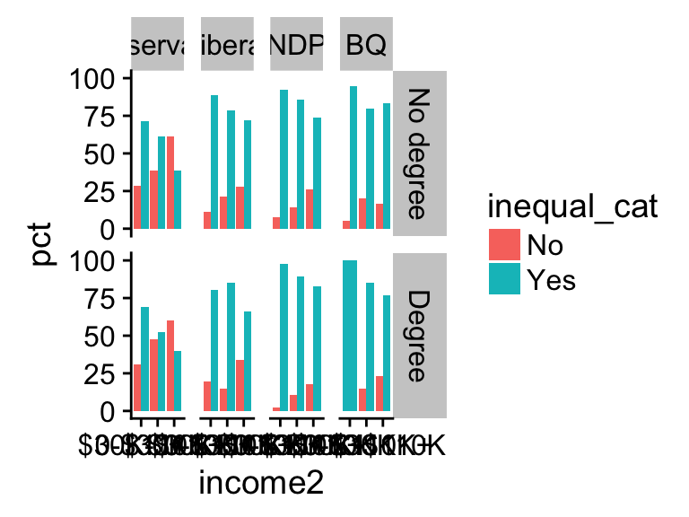

```r
#Check vals to figure out recode.
vals
#Take the data frame
ces %>%
  #select variables of interest
select(degree, vote, income, inequal_cat) %>%
  #mutate income
  mutate(income2=Recode(income, "1='0-$30K' ; 2:4='$30K-$110K' ; 5='$110K+'", levels=c('0-$30K', '$30K-$110K' , '$110K+'), as.factor=T)) %>%
  #form the groups
  group_by(degree, vote, income2, inequal_cat) %>%
  #and count
  summarize(n=n()) %>%
  #eliminate missing values
  na.omit() %>%
  #form new groups for mutating
  group_by(degree, vote, income2) %>%
  #mutate
  mutate(pct=(n/sum(n)*100)) %>%
  #plot
  ggplot(., aes(x=income2, y=pct, fill=inequal_cat))+geom_col(position='dodge')+facet_grid(degree~vote)
```

### Summarizing to calculating group means

One of the most common things that we do in the social sciences is to calculate group means. This is fundamental in experimental fields like psychology and common in fields that deal with survey research.

#### Assignment 10

> 1. Use the mean() function to calculate the average ideology scores by gender and degree status. Store the score in a new variable called `avg`. Plot them.

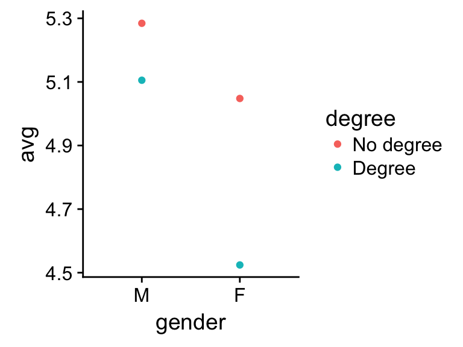

```r
ces %>%
  #name the grouping variable
  group_by(gender, degree) %>%
  #Then summarize each group by calculating its mean
  summarize(
    avg=mean(ideology, na.rm=T)
  ) %>%
na.omit() %>%
  ggplot(., aes(x=gender, y=avg, col=degree))+geom_point()
```

Conveniently, you can also use summarize to create multiple variables.

```r
ces %>%
  #name the grouping variable
  group_by(gender, degree) %>%
  na.omit() %>%
  #Then summarize each group by calculating its mean
  summarize(
    #Calculate the average
    avg=mean(ideology),
    #Calculate the standard deviation
    sd=sd(ideology),
    #calculate the number of respondents in each group with n()
  freq=n(),
  #Calculate the standard error
  se=sd/sqrt(freq)
  )
```

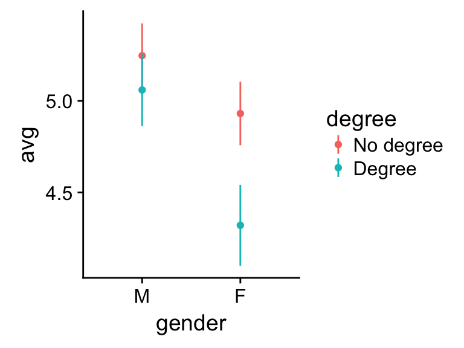

```r
ces %>%
  #name the grouping variable
  group_by(gender, degree) %>%
  na.omit() %>%
  #Then summarize each group by calculating its mean
  summarize(
    #Calculate the average
    avg=mean(ideology),
    #Calculate the standard deviation
    sd=sd(ideology),
    #calculate the number of respondents in each group with n()
  freq=n(),
  #Calculate the standard error
  se=sd/sqrt(freq)
  ) %>%
  ggplot(., aes(x=gender, y=avg))+geom_point(aes(col=degree))+geom_linerange(aes(ymin=avg-(1.96*se), ymax=avg+(1.96*se), col=degree))
```

# Generalized Linear Models

Fitting generalized linear models (e.g. logistic regression ) is easy and similar to the `lm()` command.

We can model the probability that a respondent agrees that income inequality is a big problem as follows. First we check the dependent variable

```r
#Check variables
head(ces$inequal_cat)
```

```
## [1] Yes  Yes  <NA> <NA> <NA> <NA>
## Levels: No Yes
```

note that the reference category is * No* because it is the first level. *If* we wanted to reverse that, it’s quite easy.

```r
#Option One
#Change the order of levels with levels()
levels(ces$inequal_cat)<-c('Yes', 'No')
#Show
head(ces$inequal_cat)

## Use relevel() command, #specify the reference level.
ces$inequal_cat<-relevel(ces$inequal_cat, 'No')
#Show
head(ces$inequal_cat)
```

We model it like this.

```r
#Show model
logistic1<-glm(inequal_cat ~ degree+gender, data=ces, family='binomial')
#summary
summary(logistic1)
```

```
##
## Call:
## glm(formula = inequal_cat ~ degree + gender, family = "binomial",
##     data = ces)
##
## Deviance Residuals:
##     Min       1Q   Median       3Q      Max
## -1.9653   0.5597   0.5981   0.7836   0.8334
##
## Coefficients:
##              Estimate Std. Error z value Pr(>|z|)
## (Intercept)   1.02337    0.06677   15.33   <2e-16 ***
## degreeDegree -0.14425    0.08385   -1.72   0.0854 .
## genderF       0.75112    0.08545    8.79   <2e-16 ***
## ---
## Signif. codes:  0 '***' 0.001 '**' 0.01 '*' 0.05 '.' 0.1 ' ' 1
##
## (Dispersion parameter for binomial family taken to be 1)
##
##     Null deviance: 3623.7  on 3482  degrees of freedom
## Residual deviance: 3539.4  on 3480  degrees of freedom
##   (4089 observations deleted due to missingness)
## AIC: 3545.4
##
## Number of Fisher Scoring iterations: 4
```

We can double-check this, by doing a quick table of `gender`, `degree` and `inequal_cat`. Note the command `count()`. it’s an extremely useful wrapper for the `group_by > summarize` functions above.

With one command, `count()` groups by the variables you provide, counts the number of respondents and then ungroups.

```r
#
ces %>%
  #select the three variables of interest
  select(gender, degree, inequal_cat) %>%
  #Note the function count()
  count(gender, degree, inequal_cat) %>%
  na.omit() %>%
  group_by(gender, degree) %>%
  #mutate
  mutate(pct=n/sum(n))
```

```
## # A tibble: 8 x 5
## # Groups:   gender, degree [4]
##   gender degree    inequal_cat     n   pct
##   <fct>  <fct>     <fct>       <int> <dbl>
## 1 M      No degree No            250 0.266
## 2 M      No degree Yes           689 0.734
## 3 M      Degree    No            230 0.291
## 4 M      Degree    Yes           560 0.709
## 5 F      No degree No            147 0.143
## 6 F      No degree Yes           879 0.857
## 7 F      Degree    No            121 0.166
## 8 F      Degree    Yes           607 0.834
```

```r
names(ces)
```

```
##  [1] "p_incineq"   "income_full" "p_selfplace" "education"   "p_votechce"
##  [6] "pers_ret"    "pers_fdpol"  "p_gap"       "sex_r"       "inequal"
## [11] "gender"      "degree"      "income"      "ideology"    "inequal_cat"
## [16] "personal"    "federal"     "vote"
```

#### Assignment 11

> . Use the Recode() command to recode the `vote` variable to a dichotomous variable, Conservative voter or Non-Conservative voter. Set the non-Conservative voter to be the reference level. Store the variable as `conservative`. Fit a series logistic regression models of voting for the Conservative Party, adding gender, degree, income progressively. Use stargazer() to print the results as text. Then use stargazer() to print out an html version to the desktop.

```r
names(ces)
```

```
##  [1] "p_incineq"   "income_full" "p_selfplace" "education"   "p_votechce"
##  [6] "pers_ret"    "pers_fdpol"  "p_gap"       "sex_r"       "inequal"
## [11] "gender"      "degree"      "income"      "ideology"    "inequal_cat"
## [16] "personal"    "federal"     "vote"
```

```r
#Check vote
head(ces$vote)
```

```
## [1] Conservative Conservative <NA>         <NA>         Conservative
## [6] <NA>
## Levels: Conservative Liberal NDP BQ
```

```r
#
ces$conservative<-Recode(ces$vote, "'Liberal'='Non-Conservative' ; 'NDP'='Non-Conservative' ; 'BQ'='Non-Conservative' ; 'Conservative' ='Conservative'", levels=c('Non-Conservative', 'Conservative'))
#Fit the first model
mod.con<-glm(conservative ~ gender, data=ces, family='binomial')
#UPdate
mod.con2<-update(mod.con, .~.+degree)
mod.con3<-update(mod.con2, .~.+income)
#Show
stargazer(mod.con, mod.con2, mod.con3, type='text')
```

```
##
## ==================================================
##                         Dependent variable:
##                   --------------------------------
##                             conservative
##                      (1)        (2)        (3)
## --------------------------------------------------
## genderF           -0.354***  -0.365***  -0.335***
##                    (0.077)    (0.078)    (0.081)
##
## degreeDegree                 -0.210***  -0.345***
##                               (0.079)    (0.085)
##
## income                                   0.185***
##                                          (0.032)
##
## Constant          -0.870***  -0.771***  -1.251***
##                    (0.052)    (0.063)    (0.104)
##
## --------------------------------------------------
## Observations        3,511      3,449      3,250
## Log Likelihood    -2,005.801 -1,971.105 -1,826.529
## Akaike Inf. Crit. 4,015.602  3,948.211  3,661.058
## ==================================================
## Note:                  *p<0.1; **p<0.05; ***p<0.01
```

```r
#Print out
#PC users will have to modify the path name for their desktop.
stargazer(mod.con, mod.con2, mod.con3, type='text', out='~/Desktop/conservative_models')
```

```
##
## ==================================================
##                         Dependent variable:
##                   --------------------------------
##                             conservative
##                      (1)        (2)        (3)
## --------------------------------------------------
## genderF           -0.354***  -0.365***  -0.335***
##                    (0.077)    (0.078)    (0.081)
##
## degreeDegree                 -0.210***  -0.345***
##                               (0.079)    (0.085)
##
## income                                   0.185***
##                                          (0.032)
##
## Constant          -0.870***  -0.771***  -1.251***
##                    (0.052)    (0.063)    (0.104)
##
## --------------------------------------------------
## Observations        3,511      3,449      3,250
## Log Likelihood    -2,005.801 -1,971.105 -1,826.529
## Akaike Inf. Crit. 4,015.602  3,948.211  3,661.058
## ==================================================
## Note:                  *p<0.1; **p<0.05; ***p<0.01
```

## Predicted Values from model.

We can also use `ggpredict()` to predict values.

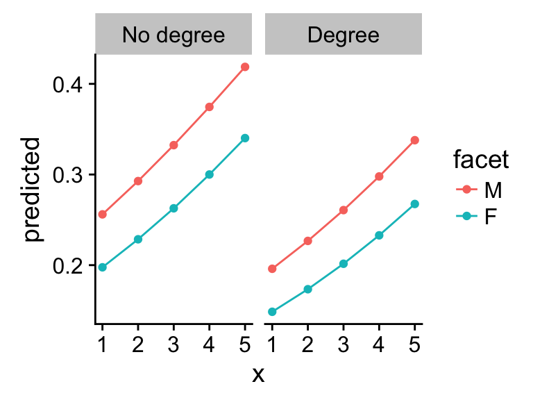

```r
ggpredict(mod.con3, terms=c('income', 'degree', 'gender')) %>%
  ggplot(., aes(x=x, y=predicted, col=facet))+facet_grid(~group)+geom_point()+geom_line()
```

# Asking for help

The best place to ask for help is [Stackexchange](http://www.stackexchange.com), specifically the sub-network [Stackoverflow](http://www.stackoverflow.com).